# ML2: Exam Preparation

Denis Baskan

14 March 2019

# Exercise: Boosting a Tree & SVM (Support-Vector-Machine)

## Load Packages

If packages are not installed, then they will be installed.

```r
required.packages =  c('gbm','e1071','ISLR','MASS')
load.packages <- function(packages){

  for (pckg in packages){
    if (!(pckg %in% installed.packages()[,"Package"])){
      install.packages(pckg)
    }

    library(pckg, character.only = TRUE)
  }
}
load.packages(required.packages)
```

# Boosted Tree Model

Let’s see how the boosted tree looks after a single iteration.

```r
set.seed (1)
#one iteration
mtcars.boost<-gbm(mpg ~ ., data=mtcars, n.trees=1,distribution="gaussian",shrinkage=0.1,bag.fraction=1)
mtcars.boost
```

```
gbm(formula = mpg ~ ., distribution = "gaussian", data = mtcars,
    n.trees = 1, shrinkage = 0.1, bag.fraction = 1)
A gradient boosted model with gaussian loss function.
1 iterations were performed.
There were 10 predictors of which 1 had non-zero influence.
```

```r
mean((mtcars$mpg-mean(mtcars$mpg))^2)  #mse of null model
```

```
[1] 35.18897
```

```r
mtcars.boost$train.error               #mse of first boost
```

```
[1] 30.8891
```

```r
#Plots
plot(mtcars$mpg,predict(mtcars.boost,n.trees=1),ylim=c(19,22),ylab="fitted values",xlab="observed values")
abline(h=mean(mtcars$mpg))
```

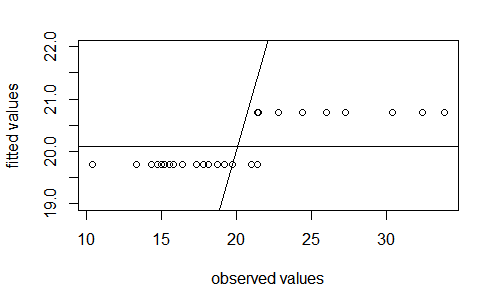

```r
abline(c(0,1))
```

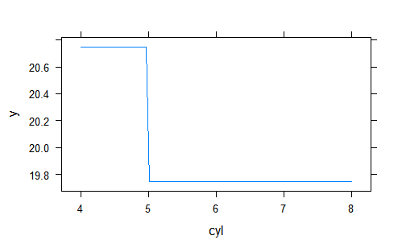

```r
plot(mtcars.boost) #effect of variable, split > 5 where the jump happens
```

Better than the Null-Model, but still not good enough for us. The horizontal line is simply the mean of outcome variable mpg. The diagonal represents the perfect fit. cyl = 5 is the value where the first split has happened.

## 2 Iterations

```r
mtcars.boost<-gbm(mpg ~ ., data=mtcars, n.trees=2,distribution="gaussian",shrinkage=0.1,bag.fraction=1)
mtcars.boost$train.error
```

```
[1] 30.8891 27.4062
```

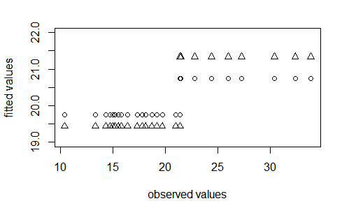

```r
plot(mtcars$mpg,predict(mtcars.boost,n.trees=1),ylim=c(19,22),ylab="fitted values",xlab="observed values")
points(mtcars$mpg,predict(mtcars.boost,n.trees=2),pch=2)
```

We can see two series of predictions in the plot. Circles and triangles each represent a tree. MSE is going down further more at least for one of the trees. Can we reduce the MSE with more iterations?

## 3 Iterations

```r
mtcars.boost<-gbm(mpg ~ ., data=mtcars, n.trees=3,distribution="gaussian",shrinkage=0.1,bag.fraction=1)
mtcars.boost$train.error
```

```
[1] 30.88910 27.40620 24.51204
```

```r
plot(mtcars$mpg,predict(mtcars.boost,n.trees=1),ylim=c(18,23),ylab="fitted values",xlab="observed values")
points(mtcars$mpg,predict(mtcars.boost,n.trees=2),pch=2)
```

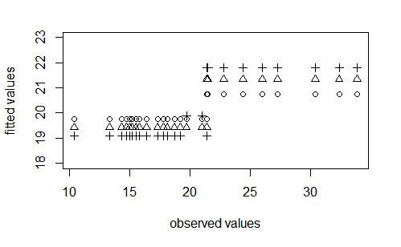

```r
points(mtcars$mpg,predict(mtcars.boost,n.trees=3),pch=3)
```

|  | var | rel.inf |
| --- | --- | --- |
| cyl | cyl | 72.89335 |
| disp | disp | 27.10665 |
| hp | hp | 0.00000 |
| drat | drat | 0.00000 |
| wt | wt | 0.00000 |
| qsec | qsec | 0.00000 |
| vs | vs | 0.00000 |
| am | am | 0.00000 |
| gear | gear | 0.00000 |
| carb | carb | 0.00000 |

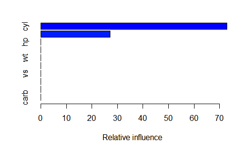

```r
summary(mtcars.boost) #relative influce of each variable
```

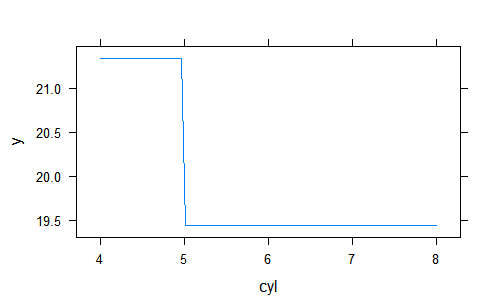

```r
plot(mtcars.boost,i.var="cyl")
```

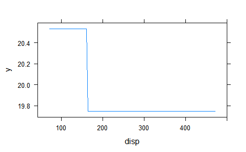

```r
plot(mtcars.boost,i.var="disp")
```

MSE is again lower with another iteration. Variables cyl and disp are by far the most important variables. For disp ~ 160 the tree has split again.

## 4 iterations

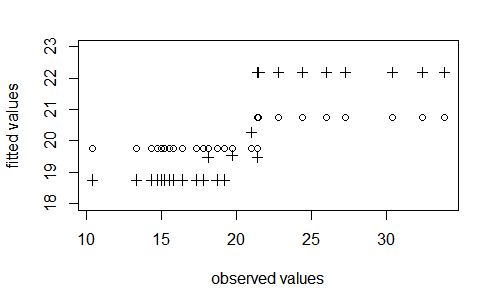

```r
mtcars.boost<-gbm(mpg ~ ., data=mtcars, n.trees=10,distribution="gaussian",shrinkage=0.1,bag.fraction=1)
plot(mtcars$mpg,predict(mtcars.boost,n.trees=1),ylim=c(18,23),ylab="fitted values",xlab="observed values")
points(mtcars$mpg,predict(mtcars.boost,n.trees=4),pch=3)
```

|  | var | rel.inf |
| --- | --- | --- |
| cyl | cyl | 59.32233 |
| disp | disp | 22.06003 |
| hp | hp | 18.61765 |
| drat | drat | 0.00000 |
| wt | wt | 0.00000 |
| qsec | qsec | 0.00000 |
| vs | vs | 0.00000 |
| am | am | 0.00000 |
| gear | gear | 0.00000 |
| carb | carb | 0.00000 |

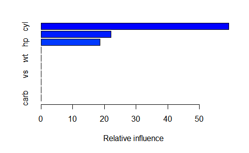

```r
summary(mtcars.boost, n.trees=4)
```

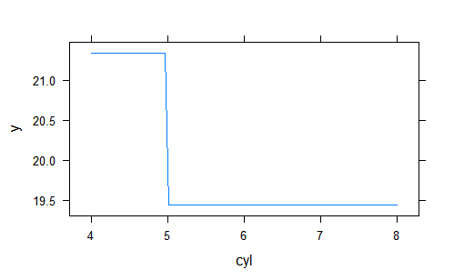

```r
plot(mtcars.boost,i.var="cyl",n.trees=4)
```

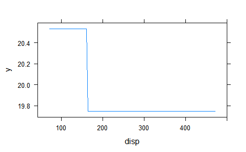

```r
plot(mtcars.boost,i.var="disp",n.trees=4)
```

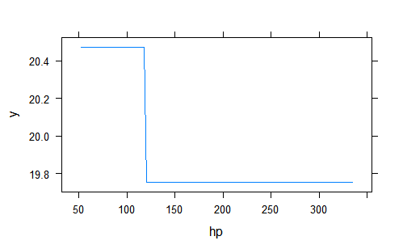

```r
plot(mtcars.boost,i.var="hp",n.trees=4)
```

The 3rd split was at a value of ~125 for the variable hp. Hence the importance of the variables cyl and disp has been declined.

## 5 iterations

|  | var | rel.inf |
| --- | --- | --- |
| cyl | cyl | 64.73876 |
| disp | disp | 19.12263 |
| hp | hp | 16.13862 |
| drat | drat | 0.00000 |
| wt | wt | 0.00000 |
| qsec | qsec | 0.00000 |
| vs | vs | 0.00000 |
| am | am | 0.00000 |
| gear | gear | 0.00000 |
| carb | carb | 0.00000 |

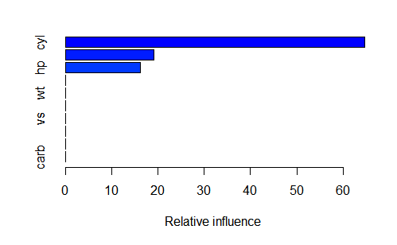

```r
summary(mtcars.boost, n.trees=5)
```

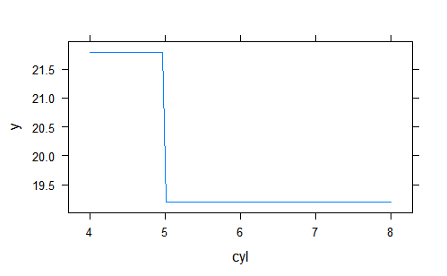

```r
plot(mtcars.boost,i.var="cyl",n.trees=5)
```

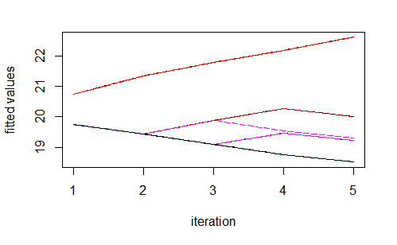

```r
matplot(t(predict(mtcars.boost,n.trees=1:5)),type="l",ylab="fitted values",xlab="iteration")
```

|  | var | rel.inf |
| --- | --- | --- |
| cyl | cyl | 49.38949 |
| disp | disp | 20.33954 |
| hp | hp | 16.38800 |
| wt | wt | 13.88297 |
| drat | drat | 0.00000 |
| qsec | qsec | 0.00000 |
| vs | vs | 0.00000 |
| am | am | 0.00000 |
| gear | gear | 0.00000 |
| carb | carb | 0.00000 |

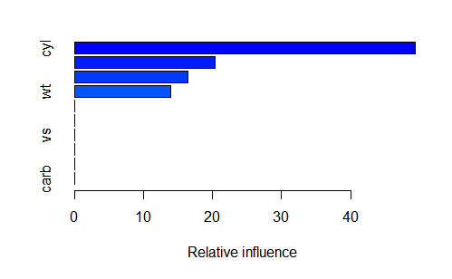

```r
summary(mtcars.boost, n.trees=10)
```

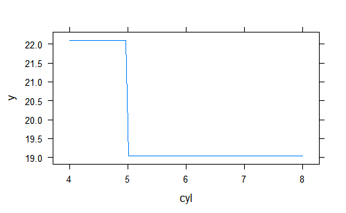

```r
plot(mtcars.boost,i.var="cyl")
```

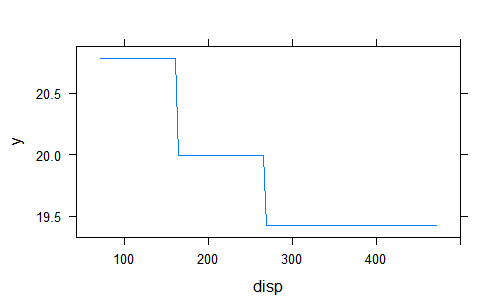

```r
plot(mtcars.boost,i.var="disp")
```

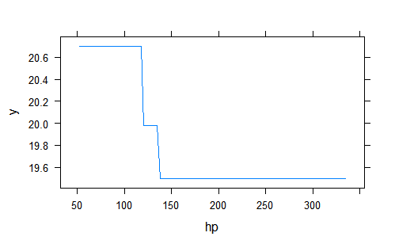

```r
plot(mtcars.boost,i.var="hp")
```

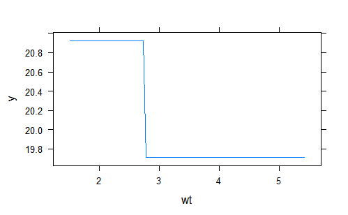

```r
plot(mtcars.boost,i.var="wt")
```

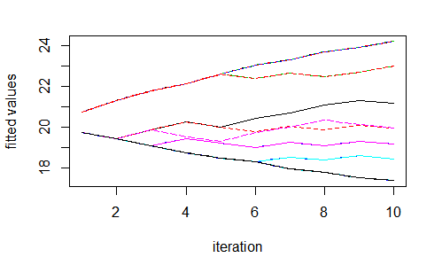

```r
matplot(t(predict(mtcars.boost,n.trees=1:10)),type="l",ylab="fitted values",xlab="iteration")
```

## 90 iterations

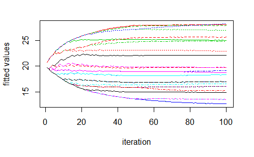

```r
mtcars.boost<-gbm.more(mtcars.boost,n.new.trees = 90)
matplot(t(predict(mtcars.boost,n.trees=1:100)),type="l",ylab="fitted values",xlab="iteration")
```

|  | var | rel.inf |
| --- | --- | --- |
| cyl | cyl | 35.5158550 |
| hp | hp | 18.0381619 |
| wt | wt | 15.1975678 |
| disp | disp | 14.9754092 |
| carb | carb | 6.0346971 |
| drat | drat | 5.7064964 |
| am | am | 1.7297626 |
| vs | vs | 1.1550008 |
| gear | gear | 0.8605528 |
| qsec | qsec | 0.7864963 |

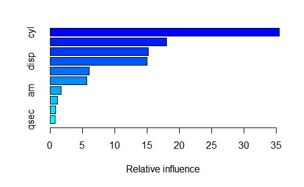

```r
summary(mtcars.boost)
```

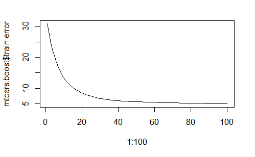

```r
plot(1:100,mtcars.boost$train.error,type="l")
```

#900 iterations

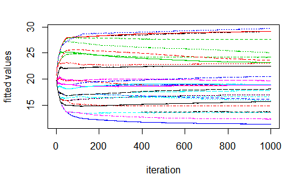

```r
mtcars.boost<-gbm.more(mtcars.boost,n.new.trees = 900)
matplot(t(predict(mtcars.boost,n.trees=1:1000)),type="l",ylab="fitted values",xlab="iteration")
```

|  | var | rel.inf |
| --- | --- | --- |
| cyl | cyl | 32.7220996 |
| hp | hp | 18.1639240 |
| wt | wt | 15.5317608 |
| disp | disp | 13.9555252 |
| drat | drat | 7.1041961 |
| carb | carb | 5.9193511 |
| vs | vs | 2.1939814 |
| qsec | qsec | 1.8398892 |
| am | am | 1.7764129 |
| gear | gear | 0.7928598 |

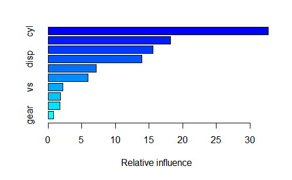

```r
summary(mtcars.boost)
```

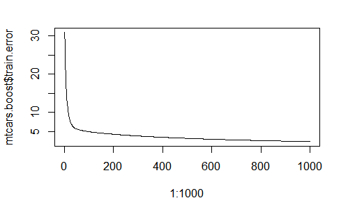

```r
plot(1:1000,mtcars.boost$train.error,type="l")
```

```r
mtcars.boost$train.error[c(1,100,1000)]
```

```
[1] 30.889100  4.961320  2.380536
```

```r
plot(mtcars$mpg,predict(mtcars.boost,n.trees=1000),ylab="fitted values",xlab="observed values")
abline(h=mean(mtcars$mpg))
```

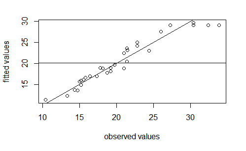

```r
abline(c(0,1))
```

The calculated error converts against 0 as expected. The difference in the error between 1 and 100 trees is tremendous, but very low between 100 and 1000 trees. The fitted values are getting closer to the observed ones.

## Try another shrinkage rate

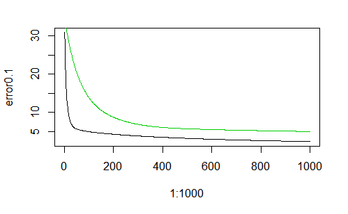

```r
error0.1<-mtcars.boost$train.error
mtcars.boost<-gbm(mpg ~ ., data=mtcars, n.trees=1000,distribution="gaussian",shrinkage=0.01,bag.fraction=1)
plot(1:1000,error0.1,type="l")
lines(1:1000,mtcars.boost$train.error,col=3)
```

Using a lower shrinkage rate results in a slower fitting model.

# SVM

The following code comes from the lab exercise 9.6.1 Support Vector Classifier in James et al.

## Have a look at our data

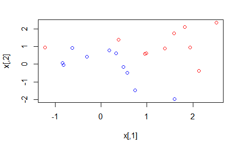

```r
set.seed(1)
x=matrix(rnorm(20*2), ncol=2)
y=c(rep(-1,10), rep(1,10))
x[y==1,]=x[y==1,] + 1
plot(x, col=(3-y))
```

You can instantly see that the data are not linearly separable.

## Create a SVM with the response as a factor variable

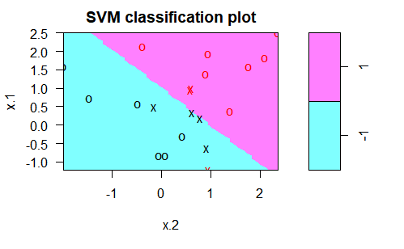

```r
dat=data.frame(x=x, y=as.factor(y))
svmfit=svm(y~., data=dat , kernel="linear", cost=10, scale=FALSE)
plot(svmfit , dat)
```

Scale = True scales each feature to have mean zero or std. dev. 1 depending on the application, but we don’t need it. We have 2 classes shown in light blue and purple. The decision boundary between the 2 classes is linear as specified. Crosses are our support vectors and the circles are the observations.

### Show the support vectors + summary

```r
svmfit$index
```

```
[1]  1  2  5  7 14 16 17
```

```r
summary(svmfit)
```

```
Call:
svm(formula = y ~ ., data = dat, kernel = "linear",
    cost = 10, scale = FALSE)


Parameters:
   SVM-Type:  C-classification
 SVM-Kernel:  linear
       cost:  10
      gamma:  0.5

Number of Support Vectors:  7

 ( 4 3 )


Number of Classes:  2

Levels:
 -1 1
```

We cann see the number of support vectors per class in the output.

## Smaller values of the cost parameter gives us…?

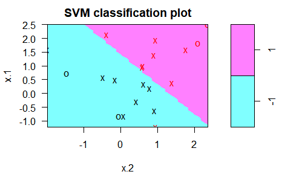

```r
svmfit=svm(y~., data=dat , kernel="linear",cost=0.1,scale=FALSE)
plot(svmfit , dat)
```

```r
svmfit$index
```

```
 [1]  1  2  3  4  5  7  9 10 12 13 14 15 16 17 18 20
```

We gained a larger number of support vectors. Unfortunately, the svm() functions does not return any information about the decision boundary or width of the margin.

# SVM with 10-fold CV

```r
set.seed(1)
tune.out=tune(svm,y~.,data=dat ,kernel="linear",
ranges=list(cost=c(0.001, 0.01, 0.1, 1,5,10,100) ))
summary(tune.out)
```

```
Parameter tuning of svm:

- sampling method: 10-fold cross validation

- best parameters:
 cost
  0.1

- best performance: 0.1

- Detailed performance results:
   cost error dispersion
1 1e-03  0.70  0.4216370
2 1e-02  0.70  0.4216370
3 1e-01  0.10  0.2108185
4 1e+00  0.15  0.2415229
5 5e+00  0.15  0.2415229
6 1e+01  0.15  0.2415229
7 1e+02  0.15  0.2415229
```

```r
bestmod=tune.out$best.model
summary(bestmod)
```

```
Call:
best.tune(method = svm, train.x = y ~ ., data = dat,
    ranges = list(cost = c(0.001, 0.01, 0.1, 1,
        5, 10, 100)), kernel = "linear")


Parameters:
   SVM-Type:  C-classification
 SVM-Kernel:  linear
       cost:  0.1
      gamma:  0.5

Number of Support Vectors:  16

 ( 8 8 )


Number of Classes:  2

Levels:
 -1 1
```

The best performance could be obtained with a cost value of 0.1.

## Generating a test set and make predictions

```r
xtest=matrix(rnorm(20*2), ncol=2)
ytest=sample(c(-1,1), 20, rep=TRUE)
xtest[ytest==1,]= xtest[ytest==1,] + 1
testdat=data.frame(x=xtest , y=as.factor(ytest))
ypred=predict(bestmod ,testdat)
table(predict=ypred , truth=testdat$y )
```

```
       truth
predict -1  1
     -1 11  1
     1   0  8
```

The predictions are really good! 19 out of 20 were correctly classified.

## Separate simulated data

Now where our data are linearly separable, the svm should find a hyperplane. We set our value of cost very large so that no observations are misclassified.

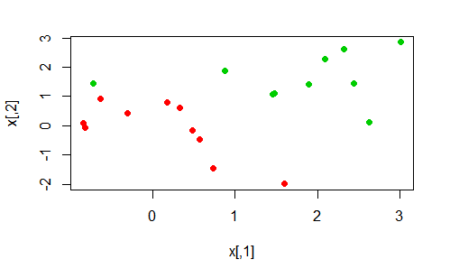

```r
x[y==1,]=x[y==1,]+0.5
plot(x, col=(y+5)/2, pch=19)
```

```r
dat=data.frame(x=x,y=as.factor(y))
svmfit=svm(y~., data=dat , kernel="linear", cost=1e5)
summary(svmfit)
```

```
Call:
svm(formula = y ~ ., data = dat, kernel = "linear",
    cost = 1e+05)


Parameters:
   SVM-Type:  C-classification
 SVM-Kernel:  linear
       cost:  1e+05
      gamma:  0.5

Number of Support Vectors:  3

 ( 1 2 )


Number of Classes:  2

Levels:
 -1 1
```

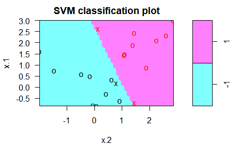

```r
plot(svmfit , dat)
```

```r
svmfit=svm(y~., data=dat , kernel="linear", cost=1)
summary(svmfit)
```

```
Call:
svm(formula = y ~ ., data = dat, kernel = "linear",
    cost = 1)


Parameters:
   SVM-Type:  C-classification
 SVM-Kernel:  linear
       cost:  1
      gamma:  0.5

Number of Support Vectors:  7

 ( 4 3 )


Number of Classes:  2

Levels:
 -1 1
```

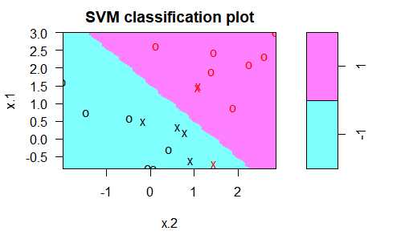

```r
plot(svmfit ,dat)
```